# Lab3

Author

Jake McDonald

```r
library(tidyverse)
library(ggridges)
library(here)

hiphop <- read_csv(here::here("supporting_artifacts", "learning_targets", "hiphop.csv"))
```

## Hip Hop Data Overview

The study asked 168 participants who were students enrolled in undergraduate linguistics, sociology, and music classes at the University of Minnesota to define 64 African-American English. This data set has 38 columns and 10752 rows, and each row represents one person’s reaction to a specific AAE vocabulary. This study examines if musical tastes, specifically a preference for hip-hop music, can predict AAE vocabulary more efficiently than ethnicity, social network phenomena, and pop-culture knowledge. The dependent variable, how familiar the students were with the vocabulary, was recorded on a scale of 1-5, with 1 being ‘not at all’, and 5 = ‘well’. Researchers also transformed this variable to binary, called faml, with ‘not at all’ coded to (0) and 2-5 coded to (1).

The social network variables, which determines how many people of color the person reacting to the vocabulary, were sometimes replaced with other values. If these values were missing, the researchers insert the values mean in the observation. The benefit of doing this is that it provides a baseline for the observations so that there is not a lot of outliers in the data. A negative to this is that it could over fit that data and not give representative results.

#1

```r
hiphop_clean <- hiphop |>
  mutate(
    sex = as.factor(sex),
    ethnic = as.factor(ethnic))
```

#2

```r
words <- distinct(hiphop_clean, word)
count(words)
```

```
# A tibble: 1 × 1
      n
  <int>
1    64
```

There are 64 unique AAE Words in this study

#3

```r
hiphop_clean <- hiphop_clean |>
  mutate(
    ethnic =
      if_else(ethnic == "white", "white", "non-white"))
```

#4

```r
ethnicity <- hiphop_clean |>
  distinct(subj, .keep_all = TRUE) |>
  count(ethnic)

ethnicity
```

```
# A tibble: 2 × 2
  ethnic        n
  <chr>     <int>
1 non-white    33
2 white       135
```

There are 135 people who identify as white and 33 people who identify as non-white in this study.

#5

```r
sex <- hiphop_clean |>
  distinct(subj, .keep_all = TRUE) |>
  count(sex)

sex
```

```
# A tibble: 2 × 2
  sex        n
  <fct>  <int>
1 Female   117
2 Male      51
```

There were 117 females and 51 males in this study.

#6

```r
age <- hiphop_clean |>
  distinct(subj, .keep_all = TRUE) |>
  select(age)
  group_by(age) |>
  count(age)
```

```
# A tibble: 21 × 2
     age     n
   <dbl> <int>
 1    16     3
 2    17    11
 3    18    69
 4    19    35
 5    20    16
 6    21    13
 7    22     5
 8    23     1
 9    24     2
10    25     1
# … with 11 more rows
```

```r
age
```

```
# A tibble: 168 × 1
     age
   <dbl>
 1    20
 2    17
 3    41
 4    18
 5    18
 6    19
 7    18
 8    18
 9    19
10    19
# … with 158 more rows
```

#7

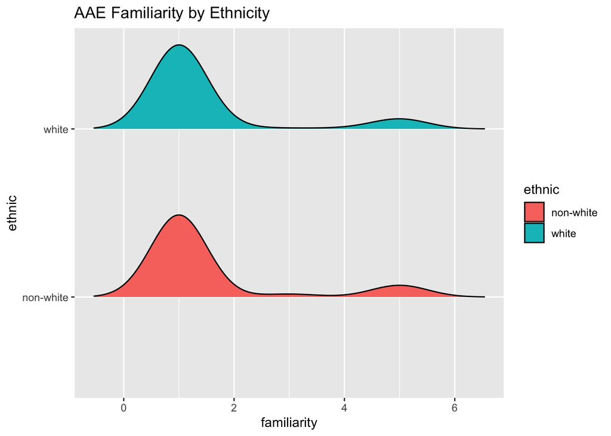

```r
hiphop_clean |>
  distinct(subj, .keep_all = TRUE) |>
  ggplot(mapping = aes(x = familiarity, y = ethnic, fill = ethnic)) +
  geom_density_ridges(scale = 0.5) +
  ggtitle("AAE Familiarity by Ethnicity")
```

#8

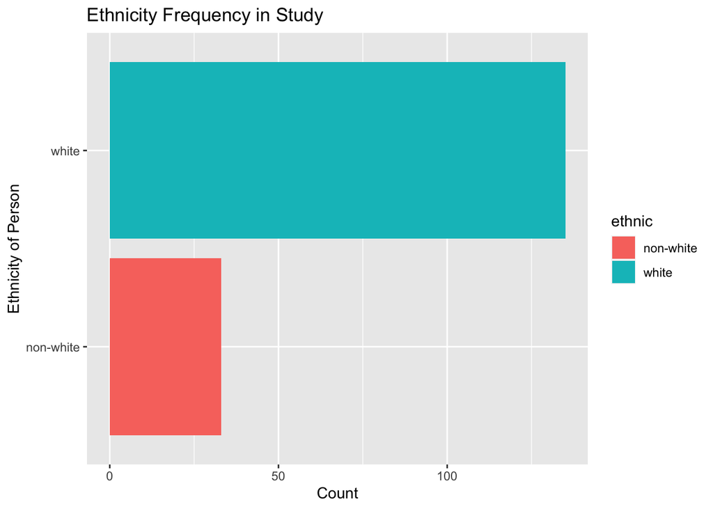

```r
ggplot(data = ethnicity,
       mapping = aes(x = n, y = ethnic, fill = ethnic)) +
  geom_col() +
  xlab("Count") +
  ylab("Ethnicity of Person") +
  ggtitle("Ethnicity Frequency in Study")
```

#9

```r
hiphop_clean |>
  filter(age < 20) |>
  group_by(word) |>
  summarize(mean = mean(familiarity)) |>
  #slice_max(mean) |>
  slice_min(mean)
```

```
# A tibble: 1 × 2
  word              mean
  <chr>            <dbl>
1 catch the vapors  1.03
```

On average, for people under 20 that participated in the study, “off the hook” was the most familiar. The least familiar for this group was ‘catch the vapors’.

#10

```r
hiphop_clean |>
  filter(sex == "Female", ethnic == "non-white") |>
  group_by(word) |>
  summarize(mean = mean(familiarity)) |>
  slice_max(mean)
```

```
# A tibble: 1 × 2
  word     mean
  <chr>   <dbl>
1 feel me  4.19
```

```r
  #slice_min(mean)
```

For non-white women, “feel me” was, on average, the most familiar to them. There was four words that all tied for the lowest familiarity, and that included “break someone out”, “dukey rope”, “plex”, and “rollie”.

#11

```r
hiphop_clean |>
  filter(sex == "Male", ethnic  == "white", age > 30) |>
  group_by(word) |>
  summarise(mean = mean(familiarity)) |>
  #slice_max(mean)
  slice_min(mean)
```

```
# A tibble: 25 × 2
   word               mean
   <chr>             <dbl>
 1 ay yo trip            1
 2 beezy                 1
 3 break someone out     1
 4 catch the vapors      1
 5 crossroads            1
 6 crump                 1
 7 dap                   1
 8 dollar cab            1
 9 domino                1
10 duckets               1
# … with 15 more rows
```

On average, the most familiar word for white males above above the age of 30 is “5 - 0”, and there are 25 words that all have a mean familiarity of only 1.

#12

```r
hiphop_clean |>
  distinct(subj, .keep_all = TRUE) |>
  filter(sex == "Male",
         ethnic == "white",
         age >= 17,
         age <= 23,
         city >= 10000,
         city <= 60000,
         bieber >= 5) |>
  pull(subj)
```

```
[1] "p17"
```

After wrangling the data, I believe that subject ‘p17’ is Justin Bieber. We filtered the observations to account for him being white and a male, between the ages of 17 and 23, and can name at least 5 Justin Bieber songs.